# Presentación del paquete `eph`

Instituto Gino Germani

Germán Rosati

Diego Kozlowski

Pablo Tiscornia

Guido Weksler

Natsumi Shokida

2019-11-14

El paquete `eph` tiene como objetivo facilitar el trabajo de les usuaries que trabajen con los microdatos de la Encuesta Permanente de Hogares. Este tutorial busca ejemplificar un pipeline de trabajo más o menos típico para mostrar el uso de las funciones del paquete.

## Instalación

Para instalar la versión estable del paquete usar:

```r
install.packages('eph')
```

Para la versión en desarrollo:

```r
# install.packages('devtools') si no tiene instalado devtools

devtools::install_github("holatam/eph")
```

## Ejemplo de flujo de trabajo

### Descarga de datos: `get_microdata()`

```r
library(eph)
library(dplyr)
library(tidyr)
library(purrr)
library(ggplot2)
```

```r
ind_3_18 <- get_microdata(year=2018, trimester=2, type='individual')
```

Puede verse que la función requiere tres argumentos básicos:

- `year`: entero con el año de la encuesta que se desea descargar
- `trimester`: entero con el trimestre (este argumento es válido para la EPH continua, 2004-actualidad)
- `type`: character `"individual"`, para descargar la base de invidividuos y `"hogar"`, para la de hogar.

```r
ind_2_02 <- get_microdata(year=2001, wave=2, type='individual')
```

### Etiquetado: `organize_labels()`

Es posible etiquetar de forma automática el dataset llamando a la función `organize_labels()`:

```r
ind_3_18 <- organize_labels(df=ind_3_18, type='individual')
```

La función toma dos argumentos:

- `df`: el data.frame que se quiere etiquetar, debe ser producto de `get_microdata()`
- `type`: string; cuál es el tipo de datatset que se quiere etiquetar, `"individual"` o `"hogar"`

Descarguemos y etiquetemos la base de hogares del 3 trimestre de 2018. Podemos hacer uso de los `%>%` pipes de `magritte`:

```r
hog_3_18 <- get_microdata(year=2018, trimester=3, type='hogar') %>%
              organize_labels(., type='hogar')
```

### Tabulados ponderados: `calculate_tabulates()`

Uno de los problemas habituales en el trabajo con la EPH es la dificultad de los diferentes softwares comerciales para la construcción de tablas de contigencia y/o distribuciones de frecuencia ponderadas. El paquete lo resuelve mediante la función `calculate_tabulates()`:

```r
calculate_tabulates(base=ind_3_18, x='ESTADO', y='CH04', weights = 'PONDIH',
                    add.totals='row', add.percentage='col')
```

```
                                                                  ESTADO/CH04  Varon  Mujer
 Entrevista individual no realizada (no respuesta al cuestionario individual)   0.0%   0.0%
                                                                      Ocupado  49.0%  35.4%
                                                                   Desocupado   4.7%   4.3%
                                                                     Inactivo  30.3%  46.7%
                                                           Menor de 10 anios.  16.0%  13.6%
                                                                        Total 100.0% 100.0%
```

Los argumentos principales de la función son:

- `base`: un data.frame proveniente de `get_microdata()`
- `x`: string con el nombre de la variable a tabular
- `y`: otro string (opcional) con el nombre de una segunda variable, para una tabla de doble entrada. Tiene que ser de igual largo que `x`
- `weights`: string con el nombre de la variable que contiene los pesos
- `add.totals`: agrega valores por `row`, `col` o `both`
- `add.percentage`: calcula porcentajes por `row`, `col` o `both`

Así, si quisiéramos la misma tabla sin ponderar:

```r
calculate_tabulates(base=ind_3_18, x='ESTADO', y='CH04',
                    add.totals='row', add.percentage='col')
```

```
                                                                  ESTADO/CH04  Varon  Mujer
 Entrevista individual no realizada (no respuesta al cuestionario individual)   0.1%   0.1%
                                                                      Ocupado  48.5%  34.0%
                                                                   Desocupado   3.6%   3.3%
                                                                     Inactivo  32.0%  48.8%
                                                           Menor de 10 anios.  15.9%  13.8%
                                                                        Total 100.0% 100.0%
```

### Armando pools de datos: `organize_panels()`

Otra potencialidad del trabajo con microdatos de la EPH es la capacidad de generar un pool de observaciones de panel. Este procedimiento consta en identificar a una misma persona u hogar encuestado en distintos trimestres, y permite realizar estudios sobre la evolución de sus caracteristicas con el correr del tiempo. Esto puede generarse, para las bases individuales en `eph` con la función `organize_panels()`. Para ello es necesario contar previamente con las múltiples bases de datos que se deseen poolear.

```r
bases <- get_microdata(year=2018, trimester=1:4, type='individual')
pool <- organize_panels(bases=bases$microdata, variables=c('ESTADO','PONDERA'),
                        window='trimestral')
```

Los argumentos principales de la función `organize_panels`son:

- `bases`: una lista con las bases de datos a poolear
- `variables`: string con los nombre de la variables de interés
- `window`: un string que indique la ventana de distancia de las observaciones (`anual`) o (`trimestral`)

```r
pool
```

| CODUSU | NRO_HOGAR | COMPONENTE | ANO4 | TRIMESTRE | CH04 | CH06 | ESTADO | PONDERA | Periodo | ANO4_t1 | TRIMESTRE_t1 | CH04_t1 | CH06_t1 | ESTADO_t1 | PONDERA_t1 | consistencia |
| --- | --- | --- | --- | --- | --- | --- | --- | --- | --- | --- | --- | --- | --- | --- | --- | --- |
| TQRMNORUTHMKKQCDEFKID00508242 | 1 | 1 | 2018 | 1 | 2 | 67 | 3 | 1008 | 2018 Q1 | 2018 | 2 | 2 | 67 | 3 | 848 | TRUE |
| TQRMNORUTHMKKQCDEFKID00508242 | 1 | 2 | 2018 | 1 | 1 | 81 | 1 | 1008 | 2018 Q1 | 2018 | 2 | 1 | 81 | 3 | 848 | TRUE |
| TQRMNORUTHMKKQCDEFKID00508242 | 1 | 3 | 2018 | 1 | 2 | 22 | 2 | 1008 | 2018 Q1 | 2018 | 2 | 2 | 23 | 2 | 848 | TRUE |
| TQRMNOVQVHMOMOCDEFKID00508196 | 1 | 1 | 2018 | 1 | 1 | 62 | 1 | 886 | 2018 Q1 | 2018 | 2 | 1 | 62 | 2 | 831 | TRUE |
| TQRMNORPYHMMLNCDEFKID00508247 | 1 | 1 | 2018 | 1 | 1 | 83 | 3 | 594 | 2018 Q1 | 2018 | 2 | 1 | 83 | 3 | 572 | TRUE |
| TQRMNORPYHMMLNCDEFKID00508247 | 1 | 2 | 2018 | 1 | 2 | 79 | 3 | 594 | 2018 Q1 | 2018 | 2 | 2 | 79 | 3 | 572 | TRUE |
| TQRMNOTSYHKMKTCDEFIAH00606143 | 1 | 1 | 2018 | 1 | 2 | 79 | 3 | 700 | 2018 Q1 | 2018 | 2 | 2 | 80 | 3 | 676 | TRUE |
| TQRMNOQTTHKMKTCDEFIAH00606144 | 1 | 1 | 2018 | 1 | 1 | 38 | 1 | 700 | 2018 Q1 | 2018 | 2 | 1 | 38 | 1 | 676 | TRUE |
| TQRMNOQTTHKMKTCDEFIAH00606144 | 1 | 2 | 2018 | 1 | 2 | 33 | 1 | 700 | 2018 Q1 | 2018 | 2 | 2 | 33 | 1 | 676 | TRUE |
| TQRMNOQRVHMMLNCDEFIAH00508001 | 1 | 1 | 2018 | 1 | 1 | 64 | 1 | 546 | 2018 Q1 | 2018 | 2 | 1 | 64 | 1 | 528 | TRUE |

[output cut: 990 more lines]

La función nos devuelve un data.frame similar a la base original, en el cual cada fila es un registro individual, que consta de las observaciones de las variables de interés específicadas, en dos periodos de tiempo. En el período inicial las mismas conservan su nombre, y en el siguiente (año o trimestre) aparecen renombradas con el agregado del string `_t1`.

Lo que hace la función detrás de bambalinas es concatenar todas las bases espeficadas en el argumento `list=` y hacer un join, conservando sólo aquellos individuos encuestados en los diferentes trimestres. La columna `consistencia` evalúa si entre ambas observaciones un mismo individuo figura con distinto sexo o con una difrencia absoluta de 2 años de edad.

```r
pool %>%
organize_labels(.) %>%
calculate_tabulates(x='ESTADO', y='ESTADO_t1',
                    weights = "PONDERA", add.percentage='row')
```

```
   ESTADO/ESTADO_t1     1     2     3     4
            Ocupado 89.0%  3.7%  7.3%  0.0%
         Desocupado 36.2% 34.8% 29.0%  0.0%
           Inactivo  7.6%  3.2% 88.9%  0.3%
 Menor de 10 anios.  0.0%  0.0%  3.8% 96.2%
```

Un indicador frecuente construido con esta infomación es la Matriz de Transición. Ella refleja como los individuos que ocupaban una determinada categoría en el período inicial, se distribuyen en cada una de las categorías en el período siguiente. La misma puede construirse sencillamente utilizando la función `calculate_tabulates`. En este ejemplo, la información refleja que durante 2018, un 3.7% de los ocupados perdió su empleo en el trimestre siguiente.

### Iterando en varias bases

Lamentablemente al no poseer una API (aplication program interface) de INDEC, el proceso de recuperación de la información debe atravesar por las bases completas. Eso implica un costo desprocionado en términos de tiempo y memoria, y por ello no se incorpora como funcionalidad del paquete. Pero en caso de ser necesario construir una serie, se podría realizar de la siguiente manera:

- crear una nueva función que descargue la información y haga un select
- mapearla sobre todos los periodos

```r
year <- 2004:2019
trimester <- c(1,3)
type<-'individual'
df <- as_tibble(expand.grid(year=year, trimester=trimester,type=type))
#defino una nueva función que haga el select
get_select <- function(year,trimester,type,vars){
  df <- get_microdata(year = year,trimester = trimester,type = type)
  if (nrow(df)==0) { #cómo hay periodos que no hay base, agregamos esta condición
    return(df)
  }else{df %>%
      rename_all(tolower) %>%  #algunos años estan en mayúscula y otros en minúscula. Normalizamos
      select(tolower(vars))} #hacemos el select para las demás bases
}
df <- df %>%
  mutate(microdata = pmap(list('year' = year,
                       'trimester' = trimester,
                       'type' = type), get_select,c('PONDERA','ESTADO','CAT_OCUP'))) %>%
  unnest()
df %>%
  sample_n(5)
```

| year | trimester | type | pondera | estado | cat_ocup |
| --- | --- | --- | --- | --- | --- |
| 2016 | 3 | individual | 415 | 1 | 1 |
| 2018 | 1 | individual | 351 | 1 | 3 |
| 2013 | 1 | individual | 65 | 1 | 2 |
| 2012 | 3 | individual | 404 | 3 | 0 |
| 2012 | 1 | individual | 1315 | 1 | 2 |

Con estos datos podemos crear por ejemplo la serie de asalarización

```r
df <- df %>%
  group_by(year,trimester) %>%
  summarise(indicador = sum(pondera[cat_ocup==3], na.rm = T) / sum(pondera[estado==1], na.rm = T))
df
```

| year | trimester | indicador |
| --- | --- | --- |
| 2004 | 1 | 0.8386363 |
| 2004 | 3 | 0.8235234 |
| 2005 | 1 | 0.8363542 |
| 2005 | 3 | 0.8177991 |
| 2006 | 1 | 0.8347151 |
| 2006 | 3 | 0.8337705 |
| 2007 | 1 | 0.8295832 |
| 2008 | 1 | 0.8254865 |
| 2008 | 3 | 0.8104491 |
| 2009 | 1 | 0.8236946 |

[output cut: 18 more lines]

### Cálculo de pobreza:

Un objetivo del paquete `eph`, es lograr automatizar el cálculo de pobreza e indigencia del INDEC para las bases trimestrales[^1]. El gran problema es que no existe información publicada fuera de los informes de prensa en formato pdf sobre los valores de las canastas básicas y alimentarias.

```r
bases <- dplyr::bind_rows(toybase_individual_2016_03,toybase_individual_2016_04)
```

Existen dos funciones núcleo:

```r
lineas <- get_poverty_lines()
lineas %>% head()
```

| periodo | CBA | ICE | CBT |
| --- | --- | --- | --- |
| 2016-04-01 | 1514.53 | 2.42 | 3663.66 |
| 2016-05-01 | 1561.35 | 2.45 | 3830.77 |
| 2016-06-01 | 1614.32 | 2.44 | 3942.67 |
| 2016-07-01 | 1666.48 | 2.42 | 4033.76 |
| 2016-08-01 | 1675.05 | 2.41 | 4041.87 |
| 2016-09-01 | 1711.22 | 2.39 | 4089.82 |

Esta función descarga los valores de las canastas alimentaria, básica (CBA y CBT) y la inversa del coeficiente de Engels… perdón, Engel (ICE) de [la serie provista por INDEC](https://www.indec.gob.ar/indec/web/Nivel4-Tema-4-43-149). Esta es la serie para GBA, y es la que publica regularmente INDEC.

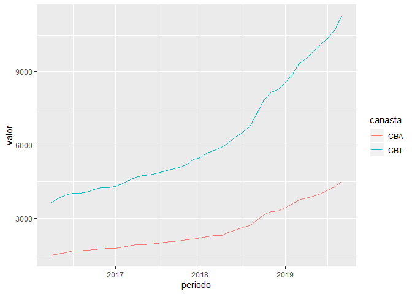

```r
lineas %>%
  select(-ICE) %>%
  gather(canasta, valor, -periodo) %>%
  ggplot() +
    geom_line(aes(x=periodo, y=valor, col=canasta))
```

Para el calculo de la Pobreza e Indigence se utilizan canastas regionales, que sólo aparecen en los [informes Técnicos](https://www.indec.gob.ar/uploads/informesdeprensa/eph_pobreza_01_19422F5FC20A.pdf).

A modo de ejemplo, en la librería `eph` se encuentra la base `canastas_reg_example` con la información necesaria para realizar el cálculo

```r
canastas_reg_example %>% head()
```

| region | periodo | CBA | CBT | codigo |
| --- | --- | --- | --- | --- |
| Cuyo | 2016.3 | 1508.807 | 3872.370 | 42 |
| Cuyo | 2016.4 | 1570.297 | 4030.407 | 42 |
| GBA | 2016.3 | 1684.250 | 4053.190 | 1 |
| GBA | 2016.4 | 1756.203 | 4232.450 | 1 |
| Noreste | 2016.3 | 1512.933 | 3413.947 | 41 |
| Noreste | 2016.4 | 1568.093 | 3538.647 | 41 |

A su vez, también se encuentra la tabla de `adulto_equivalente` que permite construir la cantidad de adultos equivalentes a nivel hogar, para multiplicar al mismo por la canasta regional correspondiente, a fin de definir la línea a nivel hogar.

```r
adulto_equivalente %>% head()
```

|  | CH04 | CH06 | adequi |
| --- | --- | --- | --- |
| 1 | 1 | -1 | 0.35 |
| 2 | 1 | 1 | 0.37 |
| 3 | 1 | 2 | 0.46 |
| 4 | 1 | 3 | 0.51 |
| 5 | 1 | 4 | 0.55 |
| 6 | 1 | 5 | 0.60 |

La función `calculate_poverty` calcula la pertenencia a situaciones de pobreza e indigencia a nivel de los individuos siguiendo la metodología de línea:

```r
bases <- dplyr::bind_rows(toybase_individual_2016_03,toybase_individual_2016_04)
base_pobreza <- calculate_poverty(base = bases, basket = canastas_reg_example,print_summary=TRUE)
```

| ANO4 | TRIMESTRE | Tasa_pobreza | Tasa_indigencia |
| --- | --- | --- | --- |
| 2016 | 3 | 0.02955128 | 0.01358740 |
| 2016 | 4 | 0.03240382 | 0.01216404 |

```r
base_pobreza %>%
  select(CODUSU,ITF,region,adequi_hogar,CBA_hogar,CBT_hogar,situacion) %>%
  sample_n(10)
```

| CODUSU | ITF | region | adequi_hogar | CBA_hogar | CBT_hogar | situacion |
| --- | --- | --- | --- | --- | --- | --- |
| TQRMNORWPHKLKTCDEGLDF00491136 | 0 | Noreste | 0.76 | 1149.8293 | 2594.599 | NA |
| TQRMNOPPRHKMLQCDEFJAH00487971 | 15000 | Pampeana | 1.00 | 1676.1633 | 4033.720 | no_pobre |
| TQRMNOSPRHMOKSCDEFOCD00489406 | 27700 | Noreste | 1.00 | 1568.0933 | 3538.647 | no_pobre |
| TQRMNOQQTHLOKSCDEIHJF00481366 | 17000 | Patagonia | 0.83 | 1440.1662 | 3936.123 | no_pobre |
| TQRMNORWQHLMKSCDEFOCD00499711 | 48800 | Noreste | 0.67 | 1050.6225 | 2370.893 | no_pobre |
| TQRMNOQWSHMNLLCDEHGHJ00502310 | 8000 | Patagonia | 0.76 | 1378.1435 | 3771.505 | no_pobre |
| TQRMNORXYHMOLTCDEFIAH00487663 | 9800 | Pampeana | 0.63 | 1100.2299 | 2651.552 | no_pobre |
| TQRMNOPXRHLLKMCDEGIBJ00473854 | 5600 | Noreste | 0.77 | 1164.9587 | 2628.739 | no_pobre |
| TQRMNOPVRHJMLMCDEGGFB00500053 | 11500 | Cuyo | 0.37 | 581.0098 | 1491.250 | no_pobre |
| TQRMNOPRTHKLKUCDEIIAD00494906 | 0 | GBA | 0.35 | 589.4875 | 1418.616 | NA |

[^1]: El calculo oficial se realiza sobre bases semestrales no publicadas